# Prediction Tunning

Gustavo Monteiro

November 2, 2018

> The database that will be used in this study consists of data on the votes that candidates for the Federal Chamber of Deputies received in the years 2006 and 2010 (source: http://www.tse.jus.br), as well as information on campaigning, party, schooling, … of them.

## Loading data.

```r
train <- read.csv("train.csv")
test <- read.csv("test.csv")
```

## Removing categoric variables.

```r
train <- train %>% select(-nome, -uf, -estado_civil,
                          -partido, -ocupacao,-ano,
                          -cargo,-grau,-sexo,
                          -sequencial_candidato)
```

> for this we will compare 3 types of regression, ridge, lasso and knn, which will be executed follow.

## Ridge regression.

```r
model
```

```
Ridge Regression

7476 samples
  13 predictors

Pre-processing: scaled (13), centered (13)
Resampling: Cross-Validated (10 fold, repeated 10 times)
Summary of sample sizes: 6731, 6728, 6728, 6728, 6729, 6728, ...
Resampling results across tuning parameters:

  lambda        RMSE       Rsquared   MAE
  1.000000e-02   37975.34  0.4032405  16936.17
  1.321941e-02   38010.94  0.4028101  16936.12
  1.747528e-02   38054.15  0.4023057  16933.45
  2.310130e-02   38105.44  0.4017440  16925.69
  3.053856e-02   38165.79  0.4011428  16911.02
  4.037017e-02   38237.15  0.4005155  16887.18
  5.336699e-02   38322.93  0.3998662  16850.71
  7.054802e-02   38428.62  0.3991861  16798.91
  9.326033e-02   38562.69  0.3984514  16728.14
  1.232847e-01   38737.85  0.3976246  16633.85
  1.629751e-01   38973.01  0.3966581  16511.35
  2.154435e-01   39296.33  0.3955037  16355.31
  2.848036e-01   39749.92  0.3941234  16158.69
  3.764936e-01   40396.20  0.3925032  15925.03
  4.977024e-01   41325.82  0.3906620  15657.56
  6.579332e-01   42665.04  0.3886538  15380.94
  8.697490e-01   44578.25  0.3865602  15177.16
  1.149757e+00   47259.19  0.3844756  15358.23
  1.519911e+00   50904.91  0.3824908  16908.97
  2.009233e+00   55672.44  0.3806783  19509.92
  2.656088e+00   61628.52  0.3790845  22804.91
  3.511192e+00   68710.23  0.3777284  26693.77
  4.641589e+00   76712.89  0.3766059  31026.37
  6.135907e+00   85311.84  0.3756971  35643.03
  8.111308e+00   94112.94  0.3749741  40335.54
  1.072267e+01  102717.29  0.3744062  44905.04
  1.417474e+01  110781.50  0.3739644  49165.62
  1.873817e+01  118058.13  0.3736233  52996.52
  2.477076e+01  124409.36  0.3733612  56332.74
```

[output cut: 59 more lines]

```
  4.641589e+08  150771.58  0.3725249  70149.03
  6.135907e+08  150771.58  0.3725249  70149.03
  8.111308e+08  150771.58  0.3725249  70149.04
  1.072267e+09  150771.58  0.3725249  70149.04
  1.417474e+09  150771.58  0.3725249  70149.04
  1.873817e+09  150771.58  0.3725249  70149.04
  2.477076e+09  150771.58  0.3725249  70149.04
  3.274549e+09  150771.58  0.3725249  70149.04
  4.328761e+09  150771.58  0.3725249  70149.04
  5.722368e+09  150771.58  0.3725249  70149.04
  7.564633e+09  150771.58  0.3725249  70149.04
  1.000000e+10  150771.58  0.3725249  70149.04

RMSE was used to select the optimal model using the smallest value.
The final value used for the model was lambda = 0.01.
```

> Variable importance for ridge regression

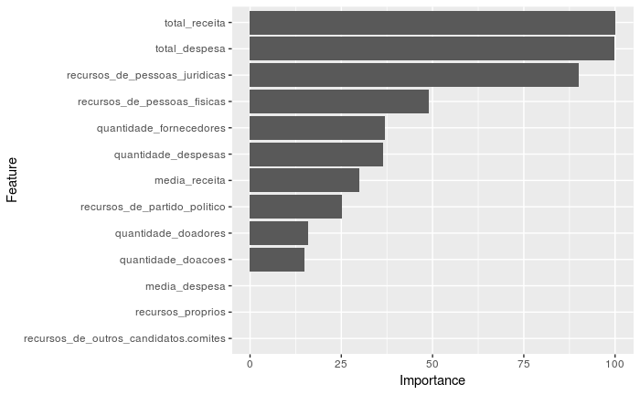

## Lasso regression.

```r
model_lasso
```

```
The lasso

7476 samples
  13 predictors

Pre-processing: centered (13), scaled (13)
Resampling: Cross-Validated (10 fold, repeated 10 times)
Summary of sample sizes: 6729, 6729, 6728, 6729, 6728, 6729, ...
Resampling results across tuning parameters:

  fraction      RMSE      Rsquared   MAE
  0.0000000100  46964.90  0.4034546  28624.33
  0.0005263253  38315.10  0.3960888  19639.19
  0.0010526405  38452.07  0.4009972  17766.75
  0.0015789558  38428.58  0.4039639  17536.65
  0.0021052711  38488.95  0.4029602  17512.22
  0.0026315863  38542.52  0.4020506  17506.00
  0.0031579016  38566.62  0.4016407  17504.58
  0.0036842168  38564.98  0.4016362  17503.38
  0.0042105321  38563.35  0.4016316  17502.18
  0.0047368474  38561.73  0.4016267  17500.98
  0.0052631626  38560.12  0.4016214  17499.77
  0.0057894779  38558.53  0.4016158  17498.57
  0.0063157932  38556.95  0.4016098  17497.37
  0.0068421084  38555.39  0.4016036  17496.17
  0.0073684237  38553.84  0.4015970  17494.98
  0.0078947389  38552.30  0.4015901  17493.79
  0.0084210542  38550.78  0.4015828  17492.59
  0.0089473695  38549.28  0.4015753  17491.40
  0.0094736847  38547.79  0.4015674  17490.21
  0.0100000000  38546.31  0.4015592  17489.02

RMSE was used to select the optimal model using the smallest value.
The final value used for the model was fraction = 0.0005263253.
```

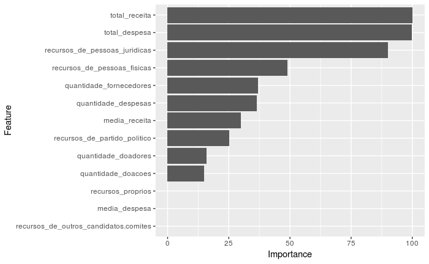

```r
ggplot(varImp(model_lasso))
```

## Knn regression.

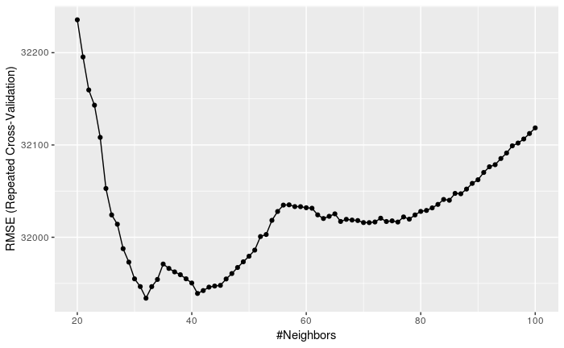

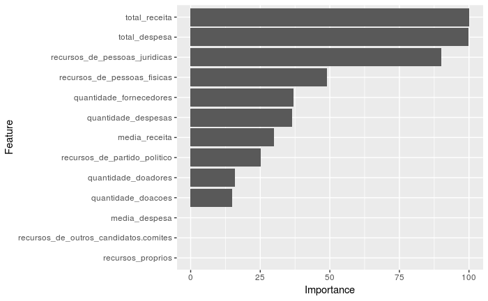

## Results

For the tests done, we see that in all models the definition of which predictors are most useful basically does not change, what was expected, having only some eventual change of position in the ranking, but in all defining the most significant variables as `total_receita`, `total_despeza`, `resources_of_personal_juridicas`.

```r
model_knn_topper
```

[output not shown]

[output cut: 40 more lines]

```
  46.5625  32398.15  0.5387294  12287.71
  46.8750  32398.15  0.5387294  12287.71
  47.1875  32382.83  0.5391538  12279.44
  47.5000  32382.83  0.5391538  12279.44
  47.8125  32382.83  0.5391538  12279.44
  48.1250  32367.47  0.5396107  12272.52
  48.4375  32367.47  0.5396107  12272.52
  48.7500  32367.47  0.5396107  12272.52
  49.0625  32357.38  0.5398857  12265.26
  49.3750  32357.38  0.5398857  12265.26
  49.6875  32357.38  0.5398857  12265.26
  50.0000  32351.17  0.5400700  12259.76

RMSE was used to select the optimal model using the smallest value.
The final value used for the model was k = 50.
```

## Generation predictions for test dataframe to submit to Kaggle, to related [competition](https://www.kaggle.com/c/ufcg-cdp-20182).

NOTE: for a delay in sending, the following prediction does not appear in the ranking, but reached a score of 30888.82009, which would fit as the third place in the public ranking had it been sent on time.

```r
prediction <- predict(model_knn, test)
data_out <- data.frame(ID = test$sequencial_candidato, votos = prediction)
data_out$ID <-as.character(data_out$ID)
data_out %>% write_csv(path = "response.csv")
prediction
```